# Fake news detection (with Random Forests)

Stefano Galelli

Term 6, 2020

First, we prepare the working environment.

```r
rm(list=ls()) # Clear the environment
# setwd("...")  # Setup the working directory
```

# 1 Data Preparation

For this simple exercise, we use existing datasets retrieved from the “Fake-News-Detection” GitHub [repository](https://github.com/chauhan-nitin/Fake-News-Detection). Here, the modelling problem is to build a classifier that detects whether a political statement from US 2016 elections is fake news (1) or not (0).

The training and testing data are ready, so we don’t need to split them, as we normally do.

```r
train <- read.csv("binary_training.csv", header=T)
test  <- read.csv("binary_testing.csv", header=T)
```

# 2 Binary classification problem

## 2.1 Training and Testing

Let’s begin with the default parameterization and see what happens.

```r
library(randomForest)
set.seed(123)
forest <- randomForest(as.factor(Label)~.,data=train)
forest
```

```
##
## Call:
##  randomForest(formula = as.factor(Label) ~ ., data = train)
##                Type of random forest: classification
##                      Number of trees: 500
## No. of variables tried at each split: 5
##
##         OOB estimate of  error rate: 40.01%
## Confusion matrix:
##      0    1 class.error
## 0 1191 3306   0.7351568
## 1  803 4969   0.1391199
```

We can see that the OOB error rate is about 40%, meaning that the model accuracy is roughly 60%. Let’s move to the test dataset.

```r
predictforest <- predict(forest,newdata=test,type="class")
table(test$Label,predictforest)
```

```
##    predictforest
##       0   1
##   0 131 425
##   1 109 618
```

The model accuracy is `0.583788`.

## 2.2 Variable importance

The term `democrat` appears to be very important.

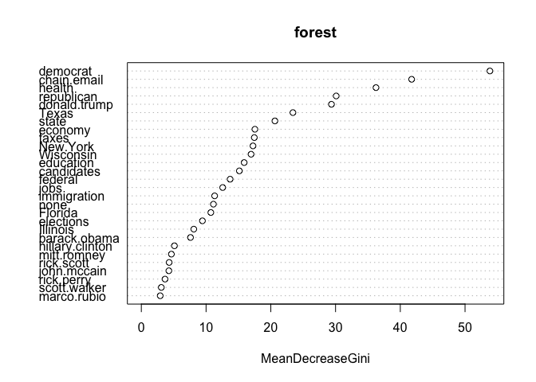

```r
# importance(forest) # tabulated results
varImpPlot(forest) # plot
```

## 2.3 Tuning the hyperparameters

Now, we repeat the experiment, but changing both `mtry` and `ntree` at the same time. Note this experiment will take some time (at least 10 minutes).

```r
# Values of ntree to be tested
B <- c(10,50,100,250,500)
# Values of mtry to be tested
m <- seq(1,20,by=1)
# Initialize a matrix for the OOB value
OOB_matrix <- matrix(0,nrow=length(B),ncol=length(m))
# For loop
for (i in 1:length(B)){
  for (j in 1:length(m)){
    # train a forest with B[i] trees
    forest_temp <- randomForest(as.factor(Label)~.,data=train,ntree=B[i],mtry=m[j])
    # model performance
    OOB_matrix[i,j] <- forest_temp$err.rate[B[i],1]
    # remove the temporary variable
    rm(forest_temp)
    }
}
# You may want to save the results
write.csv(OOB_matrix,'OOB_matrix.csv')
```

The plot below shows that the best performance is attained with `mtry` equal to about 5 and at least 250 trees (`ntree`).

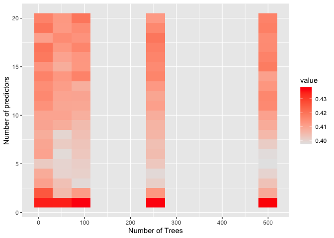

```r
# OOB_matrix <- read.csv("OOB_matrix.csv")
library(reshape2)
rownames(OOB_matrix) <- B
colnames(OOB_matrix) <- m
longData <- melt(OOB_matrix)
# plot
library(ggplot2)
ggplot(longData, aes(x = Var1, y = Var2)) +
  geom_raster(aes(fill=value)) +
  scale_fill_gradient(low="grey90", high="red") +
  labs(x="Number of Trees", y="Number of predictors")
```

Finally, let’s train and test the model with the best OOB performance.

```r
best_forest <- randomForest(as.factor(Label)~.,data=train,mtry=5,ntree=500)
best_forest
```

```
##
## Call:
##  randomForest(formula = as.factor(Label) ~ ., data = train, mtry = 5,      ntree = 500)
##                Type of random forest: classification
##                      Number of trees: 500
## No. of variables tried at each split: 5
##
##         OOB estimate of  error rate: 39.89%
## Confusion matrix:
##      0    1 class.error
## 0 1203 3294   0.7324883
## 1  802 4970   0.1389466
```

```r
predict_bestforest <- predict(best_forest,newdata=test,type="class")
table(test$Label,predict_bestforest)
```

```
##    predict_bestforest
##       0   1
##   0 133 423
##   1 110 617
```

The accuracy is `0.5845674`.